# SRM Chapter 3.1

theBudgetActuary

# **Multiple Linear Regression**

#### *Supervised/Unsupervised:* **Supervised**

#### *Type of Model:* **Regression**

#### *Parametric/Non-Parametric:* **Parametric**

#### *Tuning Parameters:* **None**

#### **Model Equation:** $\hat{y} = \hat{\beta}_{0}+\hat{\beta}_{1} x_{1}+\hat{\beta}_{2} x_{2}+...+\hat{\beta}_{p} x_{p}+\epsilon$

- $\beta_{0}$: Intercept term
- $\beta_{1..p}$: Coefficients/Slope terms
- $\epsilon$: Covers everything missed in the model such as other variables that cause variation in y, measurement error, or if the relationship between x and y is not truly linear.

# How Does MLR Work?

Previously we learned the model simple linear regression, which is just a special case of multiple linear regression in which p, or the number of predictors, is equal to one. Now we will extend on simple linear regression by adding more than one predictor. The interpretation and statistical tests used in SLR can for the most part be used in the exact same way as in multiple linear regression. With the ability to use more than one predictor we will now be able to incorporate categorical variables, interaction effects, as well as quadratic terms. The goal remains the same, to choose $\beta$ coefficients that minimize the SSE (sum of squared errors/residuals).

# Interpretation

## Numeric predictors

Numeric predictors can be interpreted the same way as with simple linear regression. ‘With a 1 unit increase in x we can expect a $\beta$ unit increase in y.’

If we were using the numeric predictors temperature and wind speed in mph to predict the rain totals in inches it would form a model equation as follows: $RainTotals = 10 + .4*temperature + 4*windSpeed$. We can say holding all else in the equation constant, with a 1 degree increase in temperature we can expect a .4 inch increase in the rain total. Wind speed can be interpreted the same way, holding all else in the equation constant, with a 1 mph increase in wind speed we can expect a 4 inch increase in rain totals. (James et al.)

## Categorical Predictors

To understand how categorical predictors are used in multiple linear regression, first there is a need to understand what a dummy variable is. A dummy variable, or binary variable, is a way to represent a qualitative variable in a numeric format.

Below we see a data set in its original format. It contains the dependent variable temperature and independent variable season. The season variable can take the values winter, spring, summer, or fall. This is the same as saying season has four levels, or can take four different values.

| temperature | season |
| --- | --- |
| 11.89401 | winter |
| 38.93231 | spring |
| 86.19397 | summer |
| 34.18598 | fall |
| 34.16144 | winter |
| 75.34560 | spring |
| 87.41792 | summer |
| 47.52836 | fall |

Below we converted the four levels from season into dummy variables.

| temperature | seasonfall | seasonspring | seasonsummer | seasonwinter |
| --- | --- | --- | --- | --- |
| 11.89401 | 0 | 0 | 0 | 1 |
| 38.93231 | 0 | 1 | 0 | 0 |
| 86.19397 | 0 | 0 | 1 | 0 |
| 34.18598 | 1 | 0 | 0 | 0 |
| 34.16144 | 0 | 0 | 0 | 1 |
| 75.34560 | 0 | 1 | 0 | 0 |
| 87.41792 | 0 | 0 | 1 | 0 |
| 47.52836 | 1 | 0 | 0 | 0 |

Since categorical variables cannot increase incrementally like numeric predictors they are instead entered in the model as their mean values, or in this case the mean temperature per season. The red X’s represent the mean value that would be entered in the model for each categorical level.

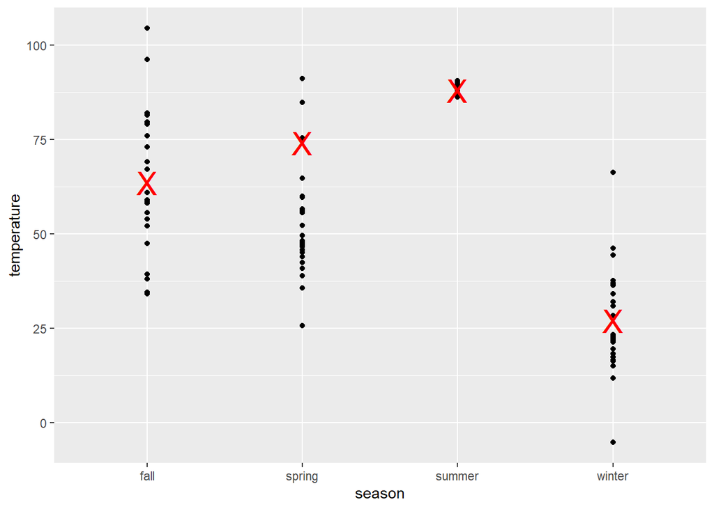

**Winter:**

$avgTemperature = \beta_{0} + \beta_{4}*humidity \rightarrow 26 + 5*humidity$

**Spring:**

$avgTemperature = \beta_{0} + \beta_{2}*summer + \beta_{4}*humidity \rightarrow 26 + 62*summer + 5*humidity$

**Fall:**

$avgTemperature = \beta_{0} + \beta_{3}*fall + \beta_{4}*humidity \rightarrow 26 + 37*fall + 5*humidity$

## Polynomial Predictors

Linear regression can use polynomial terms to model non-linear relationships between a predictor and the dependent variable. These relationships can be visualized in a scatter plot. For a simple linear regression model with a numeric predictor the model would take the form $\beta_{0} + \beta_{1}x$. Adding a quadratic term the model takes the form $\beta_{0} + \beta_{1}x + \beta_{2}x^{2}$, and a cubic term $\beta_{0} + \beta_{1}x + \beta_{2}x^{2} + \beta_{3}x^{3}$.

Although we are incorporating these extra coefficients to address non-linearity, linear regression is still a linear model. A linear model is any model that takes the form of a constant plus parameters multiplied by independent variables, or $y = \beta_{0} + \beta_{1}x_{1} + ...+\beta_{p}x_{p}$. (Frost, 2019)

If the highest power used is found to be statistically significant then keep all lower power terms, even if they are not found to be statistically significant. For example, in the equation $y = \beta_{0} + \beta_{1}x + \beta_{2}x^{2}$, if the $\beta_{2}$ parameter is found to be statistically significant keep $\beta_{1}$ even if it is not found to be statistically significant. (James et al.)

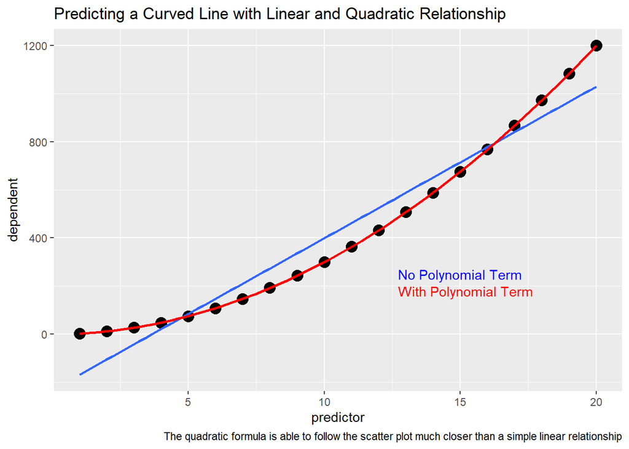

With the added polynomial term of a predictor the interpretation of the original predictor changes. For instance, earlier we used the equation $RainTotals = 10 + .4*temperature + 4*windSpeed$. In this formula we can say a 1 degree increase in temperature leads to a .4 increase in rain totals. If we add a polynomial term to our temperature: $RainTotals = 10 + .4*temperature + .4*temperature^{2} + 4*windSpeed$ the interpretation no longer stands. We can no longer say an increase in x leads to a certain increase in y because it is not a constant amount.

## Interaction Effects

We can use interaction effects in our linear regression model when the effect of an independent variable on a dependent variable changes based on the value of another independent variable. An example would be if a book manufacturer was trying to maximize sales and had two independent variables of ink and paper on hand. If the manufacturer ran out of ink it would no longer be able to make any books no matter how much paper it had, and if the manufacturer ran out of paper it would lead to the same effect. Since ink loses its ability to predict sales in a constant fashion because of another variable, an interaction term must be added. (Frost, 2019)

Adding an interaction term involves multiplying the two independent variables together and then adding another coefficient term. For example, $bookSales=\beta_{0} + \beta_{1}*ink + \beta_{2}*paper + \beta_{3} * (ink*paper)$. If the interaction term is found to be statistically significant then keep the two coefficients of the terms used to build it (i.e. if $\beta_{3}$ is significant keep $\beta_{1}$ and $\beta_{2}$).

The interpretation of the new $\beta_{3}$ parameter is the increase in effectiveness of $x_{1}$ for a 1 unit change in $x_{2}$. (Choueiry)

# Estimating Parameters

The equations of $\beta_{1} = \sqrt{MSE \left(\frac{1}{\sum(x_{i}-\bar{x})^{2}}\right)}$, and $\beta_{0}$: $\bar{y} = \beta_{0} + \beta_{1}\bar{x}$ no longer apply when we add more than one predictor. Instead, estimating parameters can be solved in two ways, gradient descent or the normal equation. Gradient descent will not be covered on this exam and the normal equation which uses linear algebra will be introduced in chapter 8 with all the other linear algebra topics on the exam (very small section).

##### **Sources:**

James, G., Witten, D., Hastie, T., & Tibshirani, R. (n.d.). An introduction to statistical learning: With applications in R.

Frost, J. (2019). Regression analysis: An intuitive guide for using and interpreting linear models. Statisics By Jim Publishing.

Choueiry, G. (n.d.). Quantifying health. Quantifying Health. Retrieved August 26, 2022, from https://quantifyinghealth.com/interpret-interactions-in-linear-regression/